# Матрицы и матричные операции.

**Матрицей** размера $m\times n$ называется прямоугольная таблица, состоящая из $m$ строк и $n$ столбцов. Элементы матрицы, обозначаемой заглавной буквой (например $A$), обычно обозначаются $a_{ij}$, где индексы $i$ и $j$ — соответственно номера строки и столбца, в которых находится элемент.

$$\begin{pmatrix} a_{11} & a_{12} & \cdots & a_{1n}\\ a_{21} & a_{22} & \cdots & a_{2n}\\ \cdots & \cdots & \ddots & \cdots \\ a_{m1} & a_{m2} & \cdots & a_{mn}\\ \end{pmatrix}$$

Числа $m$ и $n$ называют *порядками* матрицы. Если $m=n$, то матрица называется *квадратной*, а число $m=n$ — ее *порядком*.

Для краткого обозначения матрицы иногда используется символ $\left\|a_{ij}\right\|$ или выражение $A = \left\|a_{ij}\right\| = (a_{ij}) ~ (i = 1,2,...,m; ~ j = 1,2,...,n).$

В машинном обучении матрицы обычно используются для хранения информации об объектах и их признаках. При этом обычно по строкам распологаются объекты, а по столбцам — признаки (некоторые свойства объектов, значения которых используются для обучения модели и которые затем эта модель должна предсказывать для других объектов).

Векторы, изученные в предыдущих уроках, являются частными случаями матриц: в частности, упомянутые в предыдущем уроке *вектор-строка* (матрица размера $1\times m$) и *вектор-столбец* (матрица размера $n\times1$):

$$\begin{pmatrix} 1 & 2 & 3 \end{pmatrix} ~ и ~ \begin{pmatrix} 1\\ 2\\ 3 \end{pmatrix}.$$

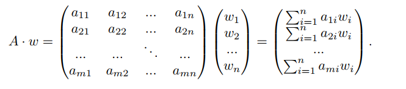

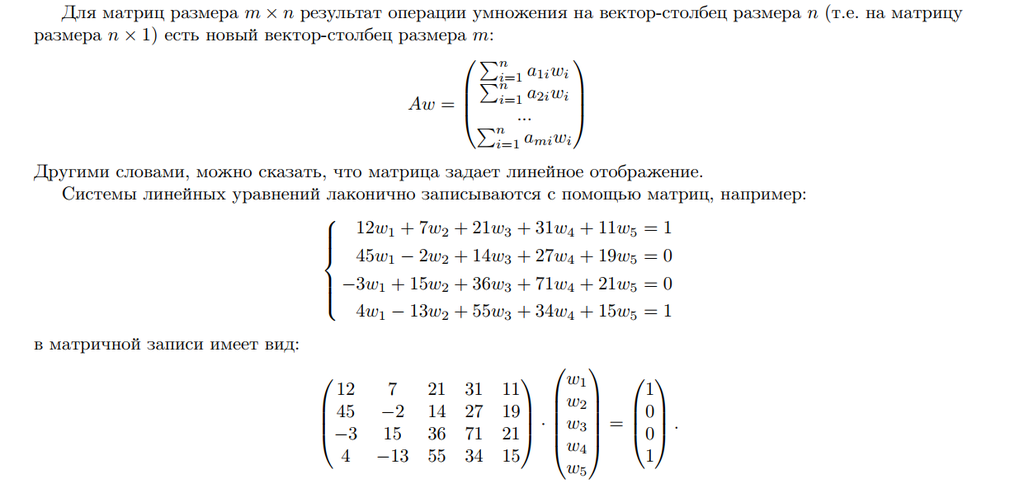

В Python работа с матрицами обычно ведется при помощи библиотеки NumPy.

```python
import numpy as np
```

Самый простой способ создать матрицу — с помощью функции `numpy.array(list, dtype=None, ...)`. Здесь `list` — список итерируемых объектов, которые составят строки матрицы. Мы уже использовали эту функцию в первом уроке для создания векторов (частный одномерный случай матриц).

```python
a = np.array([[1, 2, 3], [4, 5, 6], [7, 8, 9]])
print(f'Матрица:\n{a}')
```

```
Матрица:
[[1 2 3]
 [4 5 6]
 [7 8 9]]
```

## Матричные операции

### 1. Сложение матриц

Рассмотрим матрицы $A$ размера $m\times n$, состоящую из элементов $a_{ij}$, и $B$ того же размера, состоящую из элементов $b_{ij}$.

Складывать можно только **матрицы одинаковых порядков**, и сложение их происходит поэлементно, то есть *суммой* двух матриц $A+B$ будет являться матрица $C$ того же размера, состоящая из элементов $c_{ij}=a_{ij}+b_{ij}$:

$$A + B = \begin{pmatrix} a_{11} & a_{12} & \cdots & a_{1n}\\ a_{21} & a_{22} & \cdots & a_{2n}\\ \cdots & \cdots & \ddots & \cdots \\ a_{m1} & a_{m2} & \cdots & a_{mn}\\ \end{pmatrix} + \begin{pmatrix} b_{11} & b_{12} & \cdots & b_{1n}\\ b_{21} & b_{22} & \cdots & b_{2n}\\ \cdots & \cdots & \ddots & \cdots \\ b_{m1} & b_{m2} & \cdots & b_{mn}\\ \end{pmatrix} = \begin{pmatrix} a_{11} + b_{11} & a_{12} + b_{12} & \cdots & a_{1n} + b_{1n}\\ a_{21} + b_{21}& a_{22} + b_{22}& \cdots & a_{2n} + b_{2n}\\ \cdots & \cdots & \ddots & \cdots \\ a_{m1} + b_{m1} & a_{m2} + b_{m2} & \cdots & a_{mn} + b_{mn}\\ \end{pmatrix} = C.$$

**Пример**

Сложим две матрицы, заполненные натуральными числами:

$$\begin{pmatrix} 1 & 2 & 3\\ 4 & 5 & 6\\ 7 & 8 & 9 \end{pmatrix} + \begin{pmatrix} 1 & 1 & 1\\ 1 & 1 & 1\\ 1 & 1 & 1 \end{pmatrix} = \begin{pmatrix} 2 & 3 & 4\\ 5 & 6 & 7\\ 8 & 9 & 10 \end{pmatrix}.$$

И проведем ту же операцию при помощи Python:

```python
a = np.array([[1, 2, 3], [4, 5, 6], [7, 8, 9]])
b = np.ones((3,3))  # функция для создания матрицы размера (x,y), заполненной единицами

print(f'Матрица A\n{a}\n')
print(f'Матрица B\n{b}\n')
print(f'Матрица С = A + B\n{a + b}')
```

```
Матрица A
[[1 2 3]
 [4 5 6]
 [7 8 9]]

Матрица B
[[1. 1. 1.]
 [1. 1. 1.]
 [1. 1. 1.]]

Матрица С = A + B
[[ 2.  3.  4.]
 [ 5.  6.  7.]
 [ 8.  9. 10.]]
```

Операция сложения матриц обладает теми же свойствами, что и операция сложения вещественных чисел, а именно:  
1) $A+B=B+A;$  
2) $(A+B)+C=A+(B+C).$

### 2. Умножение матриц на число

Умножение матрицы на число происходит так же просто, как и сложение: *произведением матрицы* $A=\left\|a_{ij}\right\|$ на число $\lambda$ является матрица $C = \left\|c_{ij}\right\|$, элементы которой $c_{ij}=\lambda a_{ij}$, то есть каждый элемент матрицы умножается на число $\lambda$:

$$\lambda\cdot\begin{pmatrix} a_{11} & a_{12} & \cdots & a_{1n}\\ a_{21} & a_{22} & \cdots & a_{2n}\\ \cdots & \cdots & \ddots & \cdots \\ a_{m1} & a_{m2} & \cdots & a_{mn}\\ \end{pmatrix}= \begin{pmatrix} \lambda a_{11} & \lambda a_{12} & \cdots & \lambda a_{1n}\\ \lambda a_{21} & \lambda a_{22} & \cdots & \lambda a_{2n}\\ \cdots & \cdots & \ddots & \cdots \\ \lambda a_{m1} & \lambda a_{m2} & \cdots & \lambda a_{mn}\\ \end{pmatrix}.$$

**Пример**

$$3\cdot\begin{pmatrix} 1 & 2 & 3\\ 4 & 5 & 6\\ 7 & 8 & 9 \end{pmatrix} = \begin{pmatrix} 3 & 6 & 9\\ 12 & 15 & 18\\ 21 & 24 & 27 \end{pmatrix}.$$

Так же это происходит и в Python:

```python
a = np.array([[1, 2, 3], [4, 5, 6], [7, 8, 9]])
k = 3

print(f'Матрица А\n{a}\n')
print(f'Матрица 3*А\n{k*a}')
```

```
Матрица А
[[1 2 3]
 [4 5 6]
 [7 8 9]]

Матрица 3*А
[[ 3  6  9]
 [12 15 18]
 [21 24 27]]
```

Умножение матрицы на число обладает следующими свойствами:  
1) $(\lambda \mu)A=\lambda(\mu A);$  
2) $\lambda (A+B)=\lambda A + \lambda B;$  
3) $(\lambda + \mu) A = \lambda A + \mu A.$

### 3. Перемножение матриц

*Произведением* матрицы $A = \left\|a_{ij}\right\|$, имеющей порядки $m$ и $n$, и матрицы $B = \left\|b_{ij}\right\|$, имеющей порядки $n$ и $k$, называется матрица $C = \left\|c_{ij}\right\|$, имеющая порядки $m$ и $k$:

$$C = \begin{pmatrix} c_{11} & c_{12} & \cdots & c_{1k}\\ c_{21} & c_{22} & \cdots & c_{2k}\\ \cdots & \cdots & \ddots & \cdots\\ c_{m1} & c_{m2} & \cdots & c_{mk} \end{pmatrix},$$

наполненная элементами, определяемыми формулой

$$ c_{ij}=\sum_{p=1}^{n}a_{ip}b_{pj}.$$

Правило перемножения матриц можно сформулировать словесно следующим образом: *элемент $c*{ij}$, стоящий на пересечении $i$-й строки и $j$-го столбца матрицы $C=A\cdot B$, равен сумме попарных произведений соответствующих элементов $i$-й строки матрицы $A$ и $j$-го столбца матрицы $B$._

Следует заметить, что матрицу $A$ можно умножить не на всякую матрицу $B$: **необходимо, чтобы число столбцов матрицы $A$ было равно числу строк матрицы $B$.**

В частности, определить оба произведения $A\cdot B$ и $B\cdot A$ можно только в случае, когда число столбцов $A$ совпадает с числом строк $B$, а число строк $A$ совпадает с числом столбцов $B$. В этом случае матрицы $A\cdot B$ и $B\cdot A$ будут квадратными. Их порядок в общем случае будет различным и будет совпадать только в случае квадратных матриц $A$ и $B$.

**Пример 1**

Скалярное произведение векторов, рассмотренное нами на предыдущем уроке, можно понимать как умножение вектора-строки на вектор-столбец.

**Пример 2**

Для лучшего понимания рассмотрим в качестве примера перемножение квадратных матриц второго порядка:

$$\begin{pmatrix} a_{11} & a_{12}\\ a_{21} & a_{22} \end{pmatrix} \begin{pmatrix} b_{11} & b_{12}\\ b_{21} & b_{22} \end{pmatrix}=\begin{pmatrix} (a_{11}b_{11} + a_{12}b_{21}) & (a_{11}b_{12} + a_{12}b_{22})\\ (a_{21}b_{11} + a_{22}b_{21}) & (a_{21}b_{12} + a_{22}b_{22}) \end{pmatrix}.$$

**Пример 3**

Перемножим матрицы

$$A=\begin{pmatrix} 1 & 0\\ 2 & 1\\ 10 & 5 \end{pmatrix} \; и \; B=\begin{pmatrix} 2 & 0 & 0\\ 0 & 0 & 1 \end{pmatrix}.$$$$A\cdot B=\begin{pmatrix} 1\cdot2+0\cdot0 & 1\cdot0+2\cdot0 & 1\cdot0+0\cdot1\\ 2\cdot2+1\cdot0 & 2\cdot0+1\cdot0 & 2\cdot0+1\cdot1\\ 10\cdot2+5\cdot0 & 10\cdot0+5\cdot0 & 10\cdot0+5\cdot1 \end{pmatrix}=\begin{pmatrix} 2 & 0 & 0\\ 4 & 0 & 1\\ 20 & 0 & 5 \end{pmatrix}.$$

Сделаем то же самое при помощи Python.

В библиотеке NumPy перемножение матриц осуществляется при помощи тех же инструментов, которые мы использовали для нахождения скалярного произведения векторов, — функции `numpy.dot(a, b)` или метода `a.dot(b)`, только в этом случае `a` и `b` — матрицы.

```python
A = np.array([[1, 0], [2, 1], [10, 5]])
B = np.array([[2, 0, 0], [0, 0, 1]])

print(f'Матрица A\n{A}')
print(f'Матрица B\n{B}')
print(f'Матрица AB\n{np.dot(A, B)}')
```

```
Матрица A
[[ 1  0]
 [ 2  1]
 [10  5]]
Матрица B
[[2 0 0]
 [0 0 1]]
Матрица AB
[[ 2  0  0]
 [ 4  0  1]
 [20  0  5]]
```

Попробуем перемножить матрицы, не отвечающие правилу соответствия количества строк и столбцов:

```python
A = np.array([[1, 0], [2, 1], [10, 5]])
B = np.array([[2, 0, 0], [0, 0, 1], [0, 0, 1]])

print(f'Матрица A\n{A}')
print(f'Матрица B\n{B}')
print(f'Матрица AB\n{np.dot(A, B)}')
```

```
Матрица A
[[ 1  0]
 [ 2  1]
 [10  5]]
Матрица B
[[2 0 0]
 [0 0 1]
 [0 0 1]]
```

```
---------------------------------------------------------------------------
ValueError                                Traceback (most recent call last)
<ipython-input-16-c706fad344df> in <module>
      4 print(f'Матрица A\n{A}')
      5 print(f'Матрица B\n{B}')
----> 6 print(f'Матрица AB\n{np.dot(A, B)}')

ValueError: shapes (3,2) and (3,3) not aligned: 2 (dim 1) != 3 (dim 0)
```

Запуск кода в ячейке выше приводит к ошибке, так как количество столбцов первой матрицы не равно количеству строк второй при перемножении.

**Пример 4**

Перемножим матрицы

$$A = \begin{pmatrix} 1 & 3\\ 2 & 6 \end{pmatrix} ~ и ~ B = \begin{pmatrix} 9 & 6\\ -3 & -2 \end{pmatrix}.$$$$\begin{pmatrix} 1 & 3\\ 2 & 6 \end{pmatrix} \cdot \begin{pmatrix} 9 & 6\\ -3 & -2 \end{pmatrix} = \begin{pmatrix} 1\cdot 9 + 3\cdot (-3) & 1\cdot6 + 3\cdot (-2)\\ 2\cdot 9 + 6\cdot (-3) & 2\cdot6 + 6\cdot (-2) \end{pmatrix} = \begin{pmatrix} 0 & 0\\ 0 & 0 \end{pmatrix}. $$

Это важный пример, показывающий наличие среди матриц делителей нуля, т. е. ненулевых матриц, при перемножении дающих *нулевую матрицу*.

Из специфики произведения матриц следует, что оно не обладает свойством коммутативности, то есть $AB\neq BA$. В общем случае это справедливо даже для квадратных матриц, например:

$$\begin{pmatrix} 0 & 0\\ 0 & 1 \end{pmatrix} \begin{pmatrix} 0 & 0\\ 1 & 0 \end{pmatrix}=\begin{pmatrix} 0 & 0\\ 1 & 0 \end{pmatrix},$$$$\begin{pmatrix} 0 & 0\\ 1 & 0 \end{pmatrix}\begin{pmatrix} 0 & 0\\ 0 & 1 \end{pmatrix}=\begin{pmatrix} 0 & 0\\ 0 & 0 \end{pmatrix}.$$

Однако произведению матриц **подходящих размеров** свойственны другие особенности:

1. Ассоциативность: $(AB)C = A(BC).$

   **Доказательство**

   Возьмем матрицы $A$ размера $m\times n$, $B$ размера $n\times k$, $C$ размера $k\times l$. Тогда, по определению $i,j$-й элемент произведения матрицы $AB$ на матрицу $C$ равен:

   $$\left\{(AB)C\right\}_{ij}=\sum_{p=1}^{k}\left\{AB\right\}_{ip}c_{pj}=\sum_{p=1}^{k}\left (\sum_{q=1}^{n}a_{iq}b_{qp}\right)c_{pj}=\sum_{q=1}^{n}a_{iq}\left(\sum_{p=1}^{k}b_{qp}c_{pj}\right)=\left\{A(BC)\right\}_{ij},$$

   что и требовалось доказать.
1. Дистрибутивность: $(A+B)C = AC + BC$ и $A(B+C) = AB + AC$.

   Это свойство вытекает из определений суммы и произведения матриц.

**Возведение матриц в степень** является частным случаем перемножения:

$$A\cdot A = A^{2}.$$

**Пример**

$$\begin{pmatrix} 1 & 1\\ 0 & 1 \end{pmatrix}^{2} = \begin{pmatrix} 1 & 1\\ 0 & 1 \end{pmatrix} \cdot \begin{pmatrix} 1 & 1\\ 0 & 1 \end{pmatrix} = \begin{pmatrix} 1\cdot1 + 1\cdot0 & 1\cdot1 + 1\cdot1\\ 0\cdot1 + 1\cdot0 & 0\cdot1 + 1\cdot1 \end{pmatrix} = \begin{pmatrix} 1 & 2\\ 0 & 1 \end{pmatrix} $$

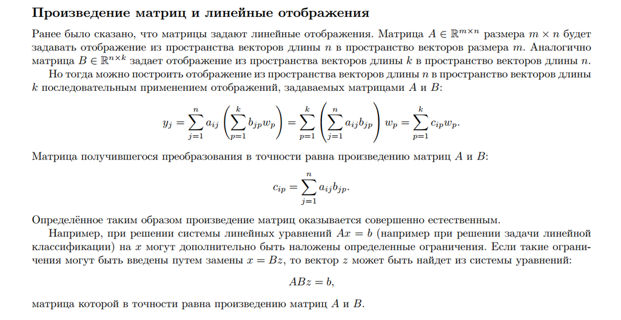

### 4. Транспонирование матриц

Рассмотрим еще одну распространенную процедуру при работе с матрицами, называемую *транспонированием.*

Пусть имеется матрица $A$ размера $m\times n$. В таком случае матрица $B$, полученная транспонированием матрицы $A$ и обозначаемая $B=A^{T}$, будет представлять собой матрицу размера $n\times m$, элементы которой $b_{ij}=a_{ji}$. Иными словами, транспонированная матрица — это матрица, отраженная относительно главной диагонали (диагональ, на которой распологаются элементы с $i=j$). При транспонировании строки исходной матрицы становятся столбцами, а столбцы — строками.

**Пример**

$$A=\begin{pmatrix} 8 & 5 & 3\\ 4 & 6 & 1\\ 0 & 11 & 9\\ 2 & 7 & 10 \end{pmatrix}, \;A^{T}=\begin{pmatrix} 8 & 4 & 0 & 2\\ 5 & 6 & 11 & 7\\ 3 & 1 & 9 & 10 \end{pmatrix}.$$

В NumPy транспонированная матрица вычисляется с помощью функции `numpy.transpose(array)` или с помощью метода `array.T`, где `array` — матрица.

```python
a = np.array([[8, 5, 3], [4, 6, 1], [0, 11, 9], [2, 7, 10]])

print(f'Матрица:\n{a}')
print(f'Транспонированная матрица:\n{a.T}')
```

```
Матрица:
[[ 8  5  3]
 [ 4  6  1]
 [ 0 11  9]
 [ 2  7 10]]
Транспонированная матрица:
[[ 8  4  0  2]
 [ 5  6 11  7]
 [ 3  1  9 10]]
```

Некоторые важные свойства транспонирования:  
1) $(A+B)^{T}=A^{T}+B^{T};$  
2) $(A\cdot B)^{T}=B^{T}\cdot A^{T}.$

## Типы матриц

Рассмотрим некоторые особые типы матриц, которые понадобятся нам в будущем, в частности, при рассмотрении темы линейных преобразований и матричных разложений.

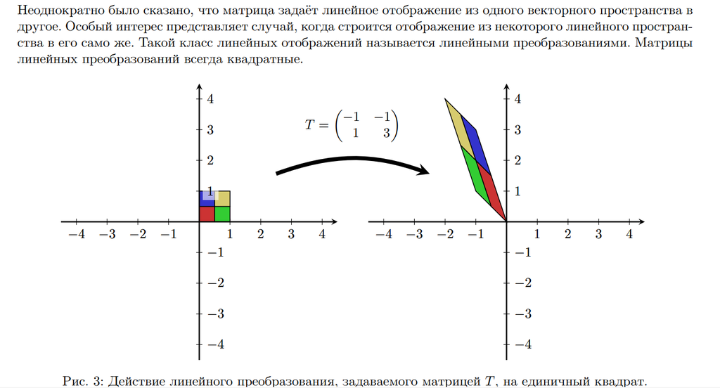

### Диагональная матрица

*Диагональная матрица* — матрица, в которой все элементы, не лежащие на главной диагонали, — нулевые:

$$D = \begin{pmatrix} d_{1} & 0 & \cdots & 0\\ 0 & d_{2} & \cdots & 0\\ \cdots & \cdots & \ddots & \cdots\\ 0 & 0 & \cdots & d_{n} \end{pmatrix}.$$

Если матрица преобразования диагональная, то она задает растяжение или сжатие по осям системы координат.

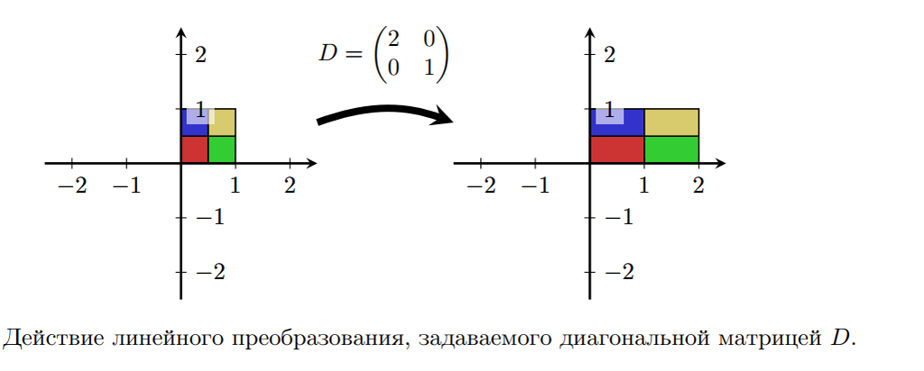

Частным случаем диагональной матрицы является *единичная матрица*, обычно обозначаемая $E$ или $I$ — это матрица, в которой главную диагональ занимают единицы, а остальные элементы — нулевые:

$$E=\begin{pmatrix} 1 & 0 & \cdots & 0\\ 0 & 1 & \cdots & 0\\ \cdots & \cdots & \ddots & \cdots\\ 0 & 0 & \cdots & 1 \end{pmatrix}.$$

В NumPy единичная матрица задается при помощи функции `numpy.eye(n)`, где `n` — порядок матрицы:

```python
e = np.eye(5)
print(f'Единичная матрица:\n{e}')
```

```
Единичная матрица:
[[1. 0. 0. 0. 0.]
 [0. 1. 0. 0. 0.]
 [0. 0. 1. 0. 0.]
 [0. 0. 0. 1. 0.]
 [0. 0. 0. 0. 1.]]
```

### Треугольная матрица

*Треугольная матрица* — квадратная матрица, у которой все элементы, стоящие ниже (или выше) главной диагонали — нулевые.

Треугольная матрица, у которой все элементы ниже главной диагонали равны нулю, называется *верхней треугольной (верхне-треугольной)* матрицей:

$$\begin{pmatrix} a_{11} & a_{12} & \cdots & a_{1n}\\ 0 & a_{22} & \cdots & a_{2n}\\ \cdots & \cdots & \ddots & \cdots \\ 0 & 0 & \cdots & a_{nn}\\ \end{pmatrix}.$$

Треугольная матрица, у которой все элементы выше главной диагонали равны нулю, называется *нижней треугольной (нижне-треугольной)* матрицей:

$$\begin{pmatrix} a_{11} & 0 & \cdots & 0\\ a_{21} & a_{22} & \cdots & 0\\ \cdots & \cdots & \ddots & \cdots \\ a_{n1} & a_{n2} & \cdots & a_{nn}\\ \end{pmatrix}.$$

Важное свойство верхне-треугольных матриц: *при перемножении верхне-треугольных матриц свойство верхней треугольности сохраняется.*

**Пример**

```python
a = np.array([[1, 2, 3, 5, 6], [0, 5, 6, 3, 1], [0, 0, 9, 7, 4], [0, 0, 0, 2, 4], [0, 0, 0, 0, 6]])
b = np.array([[1, 2, 3, 7, 1], [0, 8, 8, 5, 3], [0, 0, 5, 7, 9], [0, 0, 0, 7, 4], [0, 0, 0, 0, 2]])

print(f'Матрица A\n{a}\n')
print(f'Матрица B\n{b}\n')
print(f'Матрица AB\n{np.dot(a, b)}')
```

```
Матрица A
[[1 2 3 5 6]
 [0 5 6 3 1]
 [0 0 9 7 4]
 [0 0 0 2 4]
 [0 0 0 0 6]]

Матрица B
[[1 2 3 7 1]
 [0 8 8 5 3]
 [0 0 5 7 9]
 [0 0 0 7 4]
 [0 0 0 0 2]]

Матрица AB
[[  1  18  34  73  66]
 [  0  40  70  88  83]
 [  0   0  45 112 117]
 [  0   0   0  14  16]
 [  0   0   0   0  12]]
```

### Ортогональная матрица

Матрица $A$ называется *ортогональной*, если

$$AA^{T}=A^{T}A=E.$$

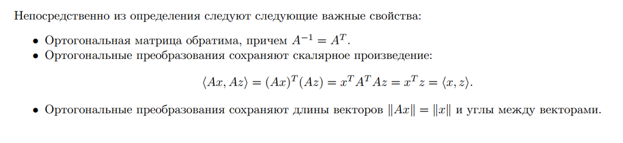

**Пример**

Ортогональной является матрица

$$\begin{pmatrix} cos\varphi & -sin\varphi\\ sin \varphi & cos\varphi \end{pmatrix}.$$

Убедимся, что это действительно так:

$$\begin{pmatrix} cos\varphi & -sin\varphi\\ sin \varphi & cos\varphi \end{pmatrix} \cdot \begin{pmatrix} cos\varphi & sin\varphi\\ -sin \varphi & cos\varphi \end{pmatrix} = \begin{pmatrix} cos\varphi \cdot cos\varphi + (-sin\varphi) \cdot (-sin\varphi) & cos\varphi \cdot sin\varphi + (-sin\varphi) \cdot cos\varphi\\ sin\varphi \cdot cos\varphi + cos\varphi \cdot (-sin\varphi) & sin\varphi \cdot sin\varphi + cos\varphi \cdot cos\varphi \end{pmatrix} = \begin{pmatrix} 1 & 0\\ 0 & 1 \end{pmatrix}.$$

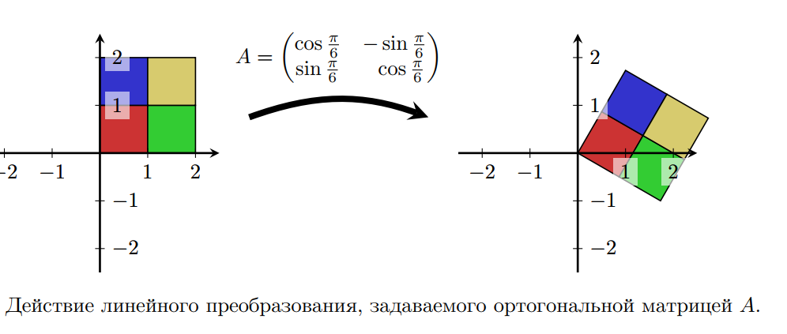

### Симметричная матрица

Матрица $A$ называется *симметричной*, если

$$A=A^{T},$$

то есть симметричная матрица симметрична относительно главной диагонали.

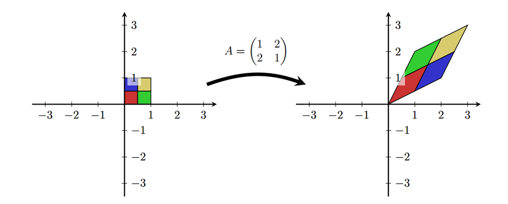

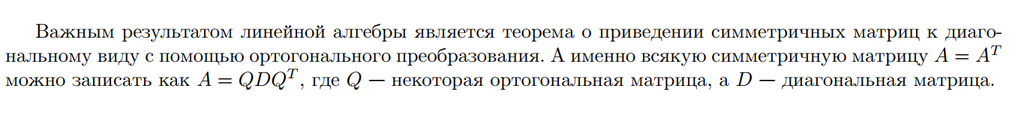

# Определитель матрицы

Рассмотрим произвольную квадратную матрицу порядка $n$:

$$A=\begin{pmatrix} a_{11} & a_{12} & \cdots & a_{1n}\\ a_{21} & a_{22} & \cdots & a_{2n}\\ \cdots & \cdots & \ddots & \cdots \\ a_{n1} & a_{n2} & \cdots & a_{nn}\\ \end{pmatrix}.$$

С каждой такой матрицей свяжем численную характеристику, называемую *определителем*, соответствующим этой матрице.

Сразу заметим, что понятие определителя имеет смысл **только для квадратных матриц**.

Если порядок $n$ матрицы равен единице, то есть эта матрица состоит из одного элемента $a_{11}$, определителем, соответствующим такой матрице, назовем сам этот элемент.

Если порядок матрицы равен $2$, то есть матрица имеет вид

$$A=\begin{pmatrix} a_{11} & a_{12}\\ a_{21} & a_{22} \end{pmatrix},$$

то определителем второго порядка, соответствующим такой матрице, назовем число, равное

$$a_{11}a_{22} - a_{12}a_{21}.$$

Словесно это правило можно сформулировать так: *определитель второго порядка, соответствующий матрице $A$, равен разности произведения элементов, стоящих на главной диагонали этой матрицы, и элементов, стоящих на ее побочной диагонали.*

Определитель матрицы $A$ обозначается как $detA$, или $|A|$, то есть определитель второго порядка можно записать как

$$detA=|A|=\begin{vmatrix} a_{11} & a_{12}\\ a_{21} & a_{22} \end{vmatrix}=a_{11}a_{22} - a_{12}a_{21}.$$

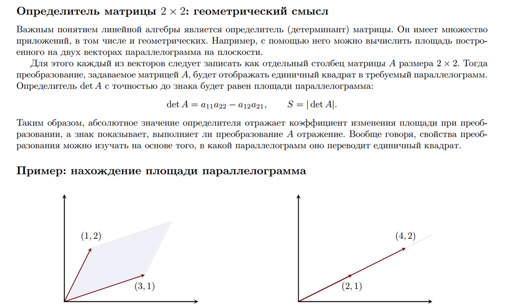

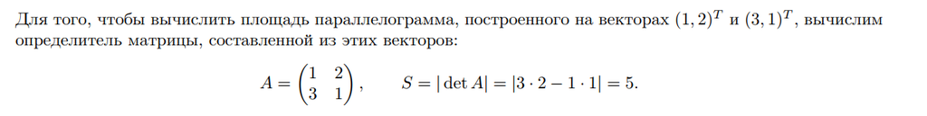

*Минором* любого элемента $a_{ij}$ матрицы $n$-го порядка назовем определитель порядка $n-1$, соответствующий матрице, которая получается из исходной матрицы путем вычеркивания $i$-й строки и $j$-го столбца (строки и столбца, на пересечении которых стоит элемент $a_{ij}$). Обозначать минор будем символом $M_{ij}$.

Определителем матрицы порядка $n$ назовем число, равное

$$detA=\begin{vmatrix} a_{11} & a_{12} & \cdots & a_{1n}\\ a_{21} & a_{22} & \cdots & a_{2n}\\ \cdots & \cdots & \ddots & \cdots \\ a_{n1} & a_{n2} & \cdots & a_{nn}\\ \end{vmatrix} = \sum_{j=1}^{n}(-1)^{j+1}a_{1j}M_{1j}.$$

Эта формула представляет собой правило составления определителя порядка $n$ по элементам первой строки и минорам $M_{1j}$, являющимися определителями порядка $n-1$.

Заметим, что при $n=2$ правило совпадает с введенным ранее правилом получения определителя для матриц второго порядка: в этом случае миноры элементов первой строки имеют вид $M_{11}=a_{22}$, $M_{12}=a_{21}$.

**Теорема**

При любом произвольном номере строки $i~(i=1,2,...,n)$ для определителя порядка $n$ справедлива формула

$$detA = \sum_{j=1}^{n}(-1)^{i+j}a_{ij}M_{ij},$$

называемая *разложением этого определителя по $i$-й строке.*

**Теорема**

При любом произвольном номере столбца $j~(j=1,2,...,n)$ для определителя порядка $n$ справедлива формула

$$detA = \sum_{i=1}^{n}(-1)^{i+j}a_{ij}M_{ij},$$

называемая *разложением этого определителя по $j$-му столбцу.*

Таким образом, определитель может быть сформирован разложением как по произвольной строке исходной матрицы, так и по произвольному ее столбцу.

**Пример**

Вычислим определитель

**Решение**

$$\begin{vmatrix} 1 & 2 & 1\\ 1 & 1 & 4\\ 2 & 3 & 6 \end{vmatrix}= 1\cdot\begin{vmatrix} 1 & 4\\ 3 & 6 \end{vmatrix}- 2\cdot\begin{vmatrix} 1 & 4\\ 2 & 6 \end{vmatrix}+ 1\cdot\begin{vmatrix} 1 & 1\\ 2 & 3 \end{vmatrix}=1\cdot(1\cdot6-3\cdot4)-2\cdot(1\cdot6-2\cdot4)+1\cdot(1\cdot3-2\cdot1)=-6+4+1=-1. $$

**Пример**

Найдем определитель матрицы

$$A=\begin{pmatrix} -1 & -4 & 0 & -2 \\ 0 & 1 & 5 & 4 \\ 3 & 1 & 1 & 0 \\ -1 & 0 & 2 & 2\\ \end{pmatrix},$$

разложив его  
1) по элементам 2-го столбца;  
2) по элементам 3-й строки.

**Решение**

1. Разложение определителяя 4-го порядка по элементам 2-го столбца будет иметь вид

$$\begin{vmatrix} a_{11} & a_{12} & a_{13} & a_{14}\\ a_{21} & a_{22} & a_{23} & a_{24}\\ a_{31} & a_{32} & a_{33} & a_{34} \\ a_{41} & a_{42} & a_{43} & a_{44}\\ \end{vmatrix} = (-1)^{1+2}a_{12}\begin{vmatrix} a_{21} & a_{23} & a_{24}\\ a_{31} & a_{33} & a_{34} \\ a_{41} & a_{43} & a_{44}\\ \end{vmatrix} + (-1)^{2+2}a_{22}\begin{vmatrix} a_{11} & a_{13} & a_{14}\\ a_{31} & a_{33} & a_{34} \\ a_{41} & a_{43} & a_{44}\\ \end{vmatrix} + (-1)^{3+2}a_{32}\begin{vmatrix} a_{11} & a_{13} & a_{14}\\ a_{21} & a_{23} & a_{24}\\ a_{41} & a_{43} & a_{44}\\ \end{vmatrix} + (-1)^{4+2}a_{42}\begin{vmatrix} a_{11} & a_{13} & a_{14}\\ a_{21} & a_{23} & a_{24}\\ a_{31} & a_{33} & a_{34} \\ \end{vmatrix}.$$

Таким образом, для матрицы $A$

$$\begin{vmatrix} -1 & -4 & 0 & -2 \\ 0 & 1 & 5 & 4 \\ 3 & 1 & 1 & 0 \\ -1 & 0 & 2 & 2\\ \end{vmatrix} = 4\begin{vmatrix} 0 & 5 & 4 \\ 3 & 1 & 0\\ -1 & 2 & 2 \\ \end{vmatrix} + \begin{vmatrix} -1 & 0 & -2\\ 3 & 1 & 0\\ -1 & 2 & 2 \\ \end{vmatrix} - \begin{vmatrix} -1 & 0 & -2\\ 0 & 5 & 4\\ -1 & 2 & 2 \\ \end{vmatrix} + 0.$$

Так задача нахождения определителя 4-го порядка сводится к нахождению трех определителей 3-го порядка. Вычислим первый, разложив по первой строке:

$$\begin{vmatrix} 0 & 5 & 4 \\ 3 & 1 & 0\\ -1 & 2 & 2 \\ \end{vmatrix} = 0\begin{vmatrix} 1 & 0\\ 2 & 2 \\ \end{vmatrix} -5\begin{vmatrix} 3 & 0\\ -1 & 2 \\ \end{vmatrix} + 4\begin{vmatrix} 3 & 1\\ -1 & 2\\ \end{vmatrix} = 0\cdot(1\cdot2-2\cdot0) -5\cdot(3\cdot2 - (-1)\cdot 0) + 4\cdot(3\cdot2 - (-1)\cdot1) = -2.$$

Аналогично вычисляем $$\begin{vmatrix} -1 & 0 & -2\\ 3 & 1 & 0\\ -1 & 2 & 2 \\ \end{vmatrix} = (-1)\begin{vmatrix} 1 & 0\\ 2 & 2 \\ \end{vmatrix} - 0\begin{vmatrix} 3 & 0\\ -1 & 2 \\ \end{vmatrix} + (-2)\begin{vmatrix} 3 & 1\\ -1 & 2 \\ \end{vmatrix} = (-1)\cdot(1\cdot2-2\cdot0) - 0\cdot(3\cdot2-(-1)\cdot0) + (-2)\cdot(3\cdot2-(-1)\cdot1) = -16,$$

$$\begin{vmatrix} -1 & 0 & -2\\ 0 & 5 & 4\\ -1 & 2 & 2 \\ \end{vmatrix} = (-1)\begin{vmatrix} 5 & 4\\ 2 & 2 \\ \end{vmatrix} - 0\begin{vmatrix} 0 & 4\\ -1 & 2 \\ \end{vmatrix} + (-2)\begin{vmatrix} 0 & 5\\ -1 & 2\\ \end{vmatrix} = (-1)\cdot(5\cdot2 - 2\cdot4) - 0\cdot(0\cdot2-(-1)\cdot4) + (-2)\cdot(0\cdot2-(-1)\cdot5) = -12.$$

Подставляя полученные значения определителей в исходное разложение, получим

$$|A| = 4\cdot(-2) + (-16) - (-12) = -12.$$

1. Разложение определителяя 4-го порядка по элементам 3-й строки будет иметь вид

$$\begin{vmatrix} a_{11} & a_{12} & a_{13} & a_{14}\\ a_{21} & a_{22} & a_{23} & a_{24}\\ a_{31} & a_{32} & a_{33} & a_{34} \\ a_{41} & a_{42} & a_{43} & a_{44}\\ \end{vmatrix} = (-1)^{3+1}a_{31}\begin{vmatrix} a_{12} & a_{13} & a_{14}\\ a_{22} & a_{23} & a_{24}\\ a_{42} & a_{43} & a_{44}\\ \end{vmatrix} + (-1)^{3+2}a_{32}\begin{vmatrix} a_{11} & a_{13} & a_{14}\\ a_{21} & a_{23} & a_{24}\\ a_{41} & a_{43} & a_{44}\\ \end{vmatrix} + (-1)^{3+3}a_{33}\begin{vmatrix} a_{11} & a_{12} & a_{14}\\ a_{21} & a_{22} & a_{24}\\ a_{41} & a_{42} & a_{44}\\ \end{vmatrix} + (-1)^{3+4}a_{34}\begin{vmatrix} a_{11} & a_{12} & a_{13}\\ a_{21} & a_{22} & a_{23}\\ a_{41} & a_{42} & a_{43} \end{vmatrix}.$$

Для матрицы $A$:

$$\begin{vmatrix} -1 & -4 & 0 & -2 \\ 0 & 1 & 5 & 4 \\ 3 & 1 & 1 & 0 \\ -1 & 0 & 2 & 2\\ \end{vmatrix} = 3\begin{vmatrix} -4 & 0 & -2 \\ 1 & 5 & 4 \\ 0 & 2 & 2\\ \end{vmatrix} -\begin{vmatrix} -1 & 0 & -2 \\ 0 & 5 & 4 \\ -1 & 2 & 2\\ \end{vmatrix} + \begin{vmatrix} -1 & -4 & -2 \\ 0 & 1 & 4 \\ -1 & 0 & 2\\ \end{vmatrix} - 0.$$

Найдем определители третьего порядка:

$$\begin{vmatrix} -4 & 0 & -2 \\ 1 & 5 & 4 \\ 0 & 2 & 2\\ \end{vmatrix} = (-4)\cdot(5\cdot2-2\cdot4) - 0\cdot(1\cdot2 - 0\cdot4) + (-2)\cdot(1\cdot2-0\cdot5)= -12,$$$$\begin{vmatrix} -1 & 0 & -2 \\ 0 & 5 & 4 \\ -1 & 2 & 2\\ \end{vmatrix} = (-1)\cdot(5\cdot2-2\cdot4) - 0\cdot(0\cdot2-(-1)\cdot4) + (-2)\cdot(0\cdot2-(-1)\cdot5)= -12,$$$$\begin{vmatrix} -1 & -4 & -2 \\ 0 & 1 & 4 \\ -1 & 0 & 2\\ \end{vmatrix} = (-1)\cdot(1\cdot2-0\cdot4) - (-4)\cdot(0\cdot2-(-1)\cdot4) + (-2)\cdot(0\cdot0-(-1)\cdot1) = 12.$$

Подставляя полученные значения определителей в исходное разложение, получим

$$|A| = 3\cdot(-12) - (-12) + 12 = -12.$$

В NumPy определитель матрицы вычисляется с помощью функции numpy.linalg.det(a), где a — матрица.

```python
import numpy as np
```

```python
a = np.array([[1, 2, 1], [1, 1, 4], [2, 3, 6]])
print(f'Матрица:\n{a}')
print(f'Определитель:\n{np.linalg.det(a):.0f}')
```

```
Матрица:
[[1 2 1]
 [1 1 4]
 [2 3 6]]
Определитель:
-1
```

```python
b = np.array([[-1, -4, 0, -2], [0, 1, 5, 4], [3, 1, 1, 0], [-1, 0, 2, 2]])
print(f'Матрица:\n{b}')
print(f'Определитель:\n{np.linalg.det(b):.0f}')
```

```
Матрица:
[[-1 -4  0 -2]
 [ 0  1  5  4]
 [ 3  1  1  0]
 [-1  0  2  2]]
Определитель:
-12
```

### Свойства определителей

**1.** Определитель транспонированной матрицы равен определителю исходной:

$$detA^{T}=detA.$$

**2.** Умножение строки или столбца матрицы на число $\lambda$ приведет к умножению определителя матрицы на то же число.

- Доказательство этого свойства элементарно, так как, исходя из формулы определителя, множитель из этой строки будет в каждом из слагаемых при нахождении определителя разложением по этой строке/столбцу, что равнозначно его умножению на это число.

**3.** Перестановка любых двух строк или столбцов матрицы приводит к изменению знака определителя.

- Это происходит из-за того, что дополнительная транспозиция меняет четность перестановки.

**4.** Если матрица имеет нулевую строку или столбец, то определитель равен нулю.

- По аналогии с пунктом 2: в каждом из слагаемых будет множитель — элемент из этой строки (столбца), а значит, все они обнулятся.

**5.** Если две строки (столбца) матрицы равны между собой, то определитель этой матрицы равен нулю.

- Согласно свойству 3, перестановка двух строк (столбцов) приводит к смене знака определителя. С другой стороны, если строки равны, то определитель измениться не должен. Оба эти условия одновременно выполняются, только когда определитель равен нулю:

$$detA=-detA \Rightarrow detA=0.$$

**6.** Если две строки (столбца) матрицы линейно зависимы, то определитель этой матрицы равен нулю.

- Согласно свойству 2, множитель строки (столбца) можно вынести за знак определителя. Вынеся таким образом множитель пропорциональности, мы получим матрицу, имеющую две одинаковых строки (столбца). Согласно свойству 5, определитель такой матрицы равен нулю.

**7.** Определитель матрицы треугольного вида равен произведению элементов, стоящих на ее главной диагонали:

$$\begin{vmatrix} a_{11} & a_{12} & a_{13} & \cdots & a_{1n}\\ 0 & a_{22} & a_{23} & \cdots & a_{2n}\\ 0 & 0 & a_{33} & \cdots & a_{3n}\\ \cdots & \cdots & \cdots & \ddots & \cdots\\ 0 & 0 & 0 & \cdots & a_{nn} \end{vmatrix}=a_{11}\cdot a_{22}\cdot ... \cdot a_{nn}.$$

**8.** Если матрица $A$ ортогональна, то определитель такой матрицы

$$detA = \pm1.$$

**9.** Для двух квадратных матриц одинакового размера

$$det(AB)=detA\cdot detB.$$

**10.** Если элементы строки (столбца) матрицы являются результатом суммы, то

$$\begin{vmatrix} a_{11} & a_{12} & a_{13} & \cdots & a_{1n}\\ \cdots & \cdots & \cdots & \cdots & \cdots\\ a_{k1}+b_{k1} & a_{k2}+b_{k2} & a_{k3}+b_{k3} & \cdots & a_{kn}+b_{kn}\\ \cdots & \cdots & \cdots & \ddots & \cdots\\ a_{1n} & a_{2n} & a_{3n} & \cdots & a_{nn} \end{vmatrix}= \begin{vmatrix} a_{11} & a_{12} & a_{13} & \cdots & a_{1n}\\ \cdots & \cdots & \cdots & \cdots & \cdots\\ a_{k1} & a_{k2} & a_{k3} & \cdots & a_{kn}\\ \cdots & \cdots & \cdots & \ddots & \cdots\\ a_{1n} & a_{2n} & a_{3n} & \cdots & a_{nn} \end{vmatrix}+ \begin{vmatrix} a_{11} & a_{12} & a_{13} & \cdots & a_{1n}\\ \cdots & \cdots & \cdots & \cdots & \cdots\\ b_{k1} & b_{k2} & b_{k3} & \cdots & b_{kn}\\ \cdots & \cdots & \cdots & \ddots & \cdots\\ a_{1n} & a_{2n} & a_{3n} & \cdots & a_{nn} \end{vmatrix}.$$

**11.** Если к одной из строк матрицы прибавить другую, умноженную на число, ее определитель не изменится:

$$\begin{vmatrix} \cdots & \cdots & \cdots & \cdots & \cdots\\ a_{i1} & a_{i2} & a_{i3} & \cdots & a_{in}\\ \cdots & \cdots & \cdots & \cdots & \cdots\\ a_{k1}& a_{k2}& a_{k3} & \cdots & a_{kn}\\ \cdots & \cdots & \cdots & \cdots & \cdots\\ \end{vmatrix}= \begin{vmatrix} \cdots & \cdots & \cdots & \cdots & \cdots\\ a_{i1} & a_{i2} & a_{i3} & \cdots & a_{in}\\ \cdots & \cdots & \cdots & \cdots & \cdots\\ a_{k1}+\lambda a_{i1} & a_{k2}+\lambda a_{i2}& a_{k3}+\lambda a_{i3} & \cdots & a_{kn}+\lambda a_{in}\\ \cdots & \cdots & \cdots & \cdots & \cdots\\ \end{vmatrix}.$$

- Такой определитель можно будет представить в виде суммы двух, первый из которых будет равен исходному, а второй будет содержать линейно зависимые строки, в связи с чем обратится в ноль.

**Пример**

Вычислим определитель

$$\begin{vmatrix} 2 & -4 & 1\\ -3 & 2 & 5\\ 1 & 2 & 3 \end{vmatrix}.$$

**Решение**

Так как при прибавлении к строке другой строки, умноженной на число, определитель не меняется, мы можем осуществить некоторые преобразования для обнуления максимального количества элементов:

- преобразуем первую строку, вычтя третью, умноженную на 2;
- преобразуем вторую строку, прибавив к ней третью, умноженную на 3.

Получим:

$$\begin{vmatrix} 2 & -4 & 1\\ -3 & 2 & 5\\ 1 & 2 & 3 \end{vmatrix}= \begin{vmatrix} 0 & -8 & -5\\ 0 & 8 & 14\\ 1 & 2 & 3 \end{vmatrix}.$$

Далее поменяем местами первую и третью строки (при этом знак определителя изменится, по свойству 3):

$$-\begin{vmatrix} 1 & 2 & 3\\ 0 & 8 & 14\\ 0 & -8 & -5 \end{vmatrix}.$$

И прибавим к третьей строке вторую:

$$-\begin{vmatrix} 1 & 2 & 3\\ 0 & 8 & 14\\ 0 & 0 & 9 \end{vmatrix}.$$

Мы получили матрицу треугольного вида, определитель которой равен произведению диагональных элементов:

$$-\begin{vmatrix} 1 & 2 & 3\\ 0 & 8 & 14\\ 0 & 0 & 9 \end{vmatrix}=-1\cdot8\cdot9=-72.$$

```python
a = np.array([[2, -4, 1], [-3, 2, 5], [1, 2, 3]])
print(f'Матрица:\n{a}')
print(f'Определитель:\n{np.linalg.det(a):.0f}')
```

```
Матрица:
[[ 2 -4  1]
 [-3  2  5]
 [ 1  2  3]]
Определитель:
-72
```

# Определение

Матрица называется *сингулярной*, или *вырожденной*, если ее определитель равен нулю.

## Ранг матрицы

Введем понятие минора $k$-го порядка.

*Минором $k$-го порядка* матрицы $A$ размера $m\times n$ будем называть определитель $k$-го порядка ($k$ не превосходит меньшее из $m$ и $n$) с элементами, лежащими на пересерчении любых $k$ строк и любых $k$ столбцов матрицы $A$.

**Определение**

Предположим, что хотя бы один из элементов матрицы $A$ отличен от нуля. Тогда найдется целое положительное число $r$, такое, что:  
1) у матрицы $A$ имеется минор $r$-го порядка, отличный от нуля;  
2) любой минор порядка $r+1$ и выше равен нулю.

Число $r$, удовлетворяющее этим требованиям, назовем *рангом матрицы $A$* и обозначим $rankA$, а минор $r$-го порядка — *базисным минором*.

Иными словами, ранг матрицы — это порядок ее максимального невырожденного (или базисного) минора.

**Определение**

*Строчным рангом матрицы* называется максимальное число линейно независимых строк этой матрицы.

*Столбцовым рангом матрицы* называется максимальное число линейно независимых столбцов этой матрицы.

**Теорема**

*Строчный ранг матрицы всегда совпадает с столбцовым и равен максимальному размеру ее невырожденного минора.*

При работе с рангом матрицы важно знать, какие преобразования матриц не приводят к изменению их ранга:

- транспонирование;
- перестановка местами двух строк (столбцов);
- умножение всех элементов строки (столбца) на число, не равное нулю;
- прибавление ко всем элементам строки (столбца) соответствующих элементов другой строки (столбца);
- выбрасывание нулевой строки (столбца);
- выбрасывание строки (столбца), являющейся линейной комбинацией других строк (столбцов).

**Пример**

Найдем ранг матрицы

$$\begin{pmatrix} 1 & 2 & 3 & 4 & 5\\ 2 & 5 & 8 & 11 & 14\\ 3 & 9 & 14 & 20 & 26\\ 5 & 14 & 22 & 31 & 40 \end{pmatrix}.$$

Четвертая строка является суммой второй и третьей строк, а значит, ее можно отбросить:

$$\begin{pmatrix} 1 & 2 & 3 & 4 & 5\\ 2 & 5 & 8 & 11 & 14\\ 3 & 9 & 14 & 20 & 26 \end{pmatrix}.$$

$$\begin{pmatrix} 1 & 2 & 3 & 4 & 5\\ 0 & 1 & 2 & 3 & 4\\ 0 & 0 & 1 & 2 & 3 \end{pmatrix}.$$

Таким образом, ранг матрицы равен $3$.

В контексте машинного обучения эта характеристика особенно важна, так как наличие линейно зависимых строк в обучающей выборке приводит к избыточности информации и усложнению модели. Такие строки из обучающих выборок можно удалять без ущерба для точности получаемой модели, осуществляя сжатие данных без потерь.

В NumPy ранг матрицы вычисляется с помощью функции `numpy.linalg.matrix_rank(a)`, где `a` — матрица.

Кроме прочего, с помощью ранга матрицы можно проверять векторы на линейную зависимость.

Имея несколько векторов, мы можем составить из них матрицу, где эти векторы будут являться строками или столбцами. Векторы будут линейно независимы тогда и только тогда, когда ранг полученной матрицы совпадет с числом векторов. .

```python
x = [1, 2, 3]
y = [2, 2, 2]
z = [3, 3, 3]

a = np.array([x, y, z])
r = np.linalg.matrix_rank(a)

print(f'Ранг матрицы: {r}')
```

```
Ранг матрицы: 2
```

# Понятие обратной матрицы

Матрица $B$ называется *правой обратной матрицей* к $A$, если

$$AB=E,$$

где $E$ — единичная матрица.

Матрица $C$ называется *левой обратной матрицей* к $A$, если

$$CA=E.$$

**Утверждение**

Если для матрицы $A$ существуют левая и правая обратные матрицы, то они совпадают между собой.

**Теорема**

Для того, чтобы для матрицы $A$ существовали левая и правая обратные матрицы, необходимо и достаточно, чтобы определитель матрицы $A$ был отличен от нуля.

Таким образом, в случае невырожденных матриц можно опускать термины «левая» и «правая», и говорить просто о матрице, *обратной по отношению к матрице* $A$, и обозначать ее символом $A^{-1}$:

$$A^{-1}A=AA^{-1}=E,$$

где $E$ — единичная матрица.

Если для матрицы $A$ существует обратная матрица, то она единственна.

*Если матрица вырождена, то у нее нет обратной матрицы.*

- **Доказательство**

Допустим, матрица $A$ вырождена, то есть $detA=0$, и для нее существует обратная матрица $A^{-1}$. Тогда из соотношения $A\cdot A^{-1}=E$ получим, что $detA\cdot detA^{-1}=detE=1$, откуда следует, что $detA\neq0$, что противоречит условию. То есть, если у матрицы есть обратная, значит, матрица невырождена. Что и требовалось доказать.

**Нахождение обратной матрицы (метод присоединенной матрицы)**

Для ввода алгоритма нахождения обратной матрицы к матрице $A$ введем понятие алгебраического дополнения.

*Алгебраическим дополнением* элемента $a_{ij}$ квадратной матрицы $A$ порядка $n$ называют минор $M_{ij}$, умноженный на $(-1)^{i+j}$, и обозначают $A_{ij}$:

$$A_{ij}=(-1)^{i+j}M_{ij}.$$

Алгоритм нахождения обратной матрицы следующий:

1. Найти определитель матрицы $A$ и убедиться, что $detA\neq0$;
2. Составить алгебраические дополнения $A_{ij}$ для каждого элемента матрицы $A$ и записать матрицу $A^{*}=(A_{ij})$ из найденных алгебраических дополнений.
3. Записать обратную матрицу, определенную по формуле

$$A^{-1}=\frac{1}{detA}\cdot A^{*T}.$$

Матрицу $A^{*T}$ часто называют *присоединенной (союзной)* к матрице $A$.

**Пример**

Найдем обратную матрицу для матрицы

$$A = \begin{pmatrix} 1 & 2 & 1\\ 1 & 1 & 4\\ 2 & 3 & 6 \end{pmatrix}.$$

**Решение**

1. Найдем определитель:

$$\begin{vmatrix} 1 & 2 & 1\\ 1 & 1 & 4\\ 2 & 3 & 6 \end{vmatrix} = -6 + 4 + 1 = -1. $$

1. Найдем алгебраические дополнения для каждого элемента:

$$A_{11}=(-1)^{2}\begin{vmatrix} 1 & 4\\ 3 & 6 \end{vmatrix} = -6,~ A_{12}=(-1)^{3}\begin{vmatrix} 1 & 4\\ 2 & 6 \end{vmatrix} = 2,~ A_{13}=(-1)^{4}\begin{vmatrix} 1 & 1\\ 2 & 3 \end{vmatrix} = 1,$$$$A_{21}=(-1)^{3}\begin{vmatrix} 2 & 1\\ 3 & 6 \end{vmatrix} = -9,~ A_{22}=(-1)^{4}\begin{vmatrix} 1 & 1\\ 2 & 6 \end{vmatrix} = 4,~ A_{23}=(-1)^{5}\begin{vmatrix} 1 & 2\\ 2 & 3 \end{vmatrix} = 1,$$$$A_{31}=(-1)^{4}\begin{vmatrix} 2 & 1\\ 1 & 4\\ \end{vmatrix} = 7,~ A_{32}=(-1)^{5}\begin{vmatrix} 1 & 1\\ 1 & 4 \end{vmatrix} = -3,~ A_{33}=(-1)^{6}\begin{vmatrix} 1 & 2\\ 1 & 1\\ \end{vmatrix} = -1.$$

Полученная матрица из алгебраических дополнений:

$$A^{*} = \begin{pmatrix} -6 & 2 & 1\\ -9 & 4 & 1\\ 7 & -3 & -1 \end{pmatrix},~ A^{*T} = \begin{pmatrix} -6 & -9 & 7\\ 2 & 4 & -3\\ 1 & 1 & -1 \end{pmatrix}.$$

1. Используя формулу из алгоритма, получим

$$A^{-1} = \frac{1}{(-1)}\cdot \begin{pmatrix} -6 & -9 & 7\\ 2 & 4 & -3\\ 1 & 1 & -1 \end{pmatrix} = \begin{pmatrix} 6 & 9 & -7\\ -2 & -4 & 3\\ -1 & -1 & 1 \end{pmatrix}.$$

В NumPy обратные матрицы вычисляются с помощью функции `numpy.linalg.inv(a)`, где `a` — матрица.

```python
a = np.array([[1, 2, 1], [1, 1, 4], [2, 3, 6]], dtype=float)
b = np.linalg.inv(a)

print(f'Матрица A:\n{a}\n')
print(f'Матрица B, обратная к A:\n{b}\n')
print(f'Матрица AB (должна быть единичной):\n{a.dot(b)}')
```

```
Матрица A:
[[1. 2. 1.]
 [1. 1. 4.]
 [2. 3. 6.]]

Матрица B, обратная к A:
[[ 6.  9. -7.]
 [-2. -4.  3.]
 [-1. -1.  1.]]

Матрица AB (должна быть единичной):
[[1. 0. 0.]
 [0. 1. 0.]
 [0. 0. 1.]]
```

# Линейные преобразования векторных пространств

Кроме введенных нами ранее операций для векторов (сложение, умножение на число, скалярное произведение) часто возникает необходимость производить над векторами и другие операции — например, растягивание, поворот и т. д. То есть нам необходимо каждому вектору поставить в соответствие другой вектор согласно некоторому правилу. Такое отображение, согласно которому каждому элементу $x$ линейного пространства $V$ поставлен в соответствие элемент $y$ пространства $W$, называется *оператором* из $V$ в $W$:

$$\textbf{A} :V\rightarrow W, ~ x\mapsto y.$$

Линейное преобразование — это преобразование, переводящее вектор $x$ линейного пространства $V$ в вектор $y$ того же пространства:

$$\textbf{A}x=y.$$

При этом $y$ называется *образом* элемента $x$, а $x$ — *прообразом* элемента $y$.

Любая квадратная матрица размера $n\times n$ может рассматриваться как линейный оператор, переводящий вектор $x$ $n$-мерного пространства в вектор $y$ того же пространства.

**Геометрический смысл** линейного преобразования, заданного матрицей

$$A=\begin{pmatrix} a & b\\ c & d \end{pmatrix},$$

можно выразить как преобразование единичного квадрата в параллелограмм с вершинами $(0,0),~(a,b),~(a+c,b+d),~(c,d)$. При этом определитель матрицы линейного оператра иллюстрирует, во сколько раз площадь полученного параллелограмма будет превышать площадь исходного единичного квадрата.

Пример 1. Вначале изобразим базис из векторов $e_{1}=(1,0)$ и $e_{2}=(0,1)$ в двумерном пространстве:

```python
# запустите последовательно код в ячейках,чтобы отобразить иллюстрации
import matplotlib.pyplot as plt
```

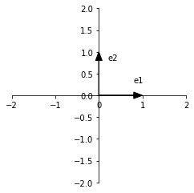

```python
fig = plt.figure()
ax = fig.add_subplot(1,1,1)

ax.spines['left'].set_position('zero')
ax.spines['bottom'].set_position('zero')

ax.spines['right'].set_color('none')
ax.spines['top'].set_color('none')

plt.axis('scaled')
plt.xlim(-2, 2)
plt.ylim(-2, 2)

ax.arrow(0, 0, 0, 1, head_width=0.15, head_length=0.2, length_includes_head=True, facecolor='black')
ax.arrow(0, 0, 1, 0, head_width=0.15, head_length=0.2, length_includes_head=True, facecolor='black')
ax.annotate("e1", xy=(0.8, 0.3))
ax.annotate("e2", xy=(0.2, 0.8))

plt.show()
```

# Применим к нему произвольное линейное преобразование, заданное матрицей

$$A=\begin{pmatrix} 0 & -1\\ 1 & 0 \end{pmatrix}.$$

Векторы коэффициентов разложения векторов $g_{i}$ по базису задают столбцы матрицы линейного оператора. Тогда базисные векторы преобразуются следующим образом:

$$Ae_{1}=0\cdot e_{1}+1\cdot e_{2}=e_{2},$$$$Ae_{2}=-1\cdot e_{1}+0\cdot e_{2}=-e_{1}.$$

# Изобразим получившийся базис:

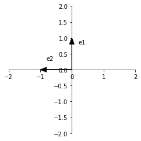

```python
fig = plt.figure()
ax = fig.add_subplot(1,1,1)

ax.spines['left'].set_position('zero')
ax.spines['bottom'].set_position('zero')

ax.spines['right'].set_color('none')
ax.spines['top'].set_color('none')

plt.axis('scaled')
plt.xlim(-2, 2)
plt.ylim(-2, 2)

ax.arrow(0, 0, 0, 1, head_width=0.15, head_length=0.2, length_includes_head=True, facecolor='black')
ax.arrow(0, 0, -1, 0, head_width=0.15, head_length=0.2, length_includes_head=True, facecolor='black')
ax.annotate("e2", xy=(-0.8, 0.3))
ax.annotate("e1", xy=(0.2, 0.8))

plt.show()
```

То есть мы получили поворот базиса на 90 градусов.

На самом деле заданная нами матрица 𝐴 являлась ортогональной. Преобразования, заданные ортогональными матрицами, являются поворотом или поворотом с инверсией, и в общем случае матрица такого преобразования с поворотом на угол 𝜑 имеет вид

$$\begin{pmatrix} cos \varphi & sin \varphi\\ -sin \varphi & cos \varphi \end{pmatrix} \; \text{или} \; \begin{pmatrix} cos \varphi & -sin \varphi\\ sin \varphi & cos \varphi \end{pmatrix}.$$

**Пример 2**

Преобразование, заданное невырожденной **диагональной** матрицей, представляет собой растяжение или сжатие относительно координатных осей.

Рассмотрим те же базисные векторы $e_{1}$ и $e_{2}$ и действие на них линейного оператора, заданного матрицей

$$\begin{pmatrix} 1 & 0\\ 0 & 2 \end{pmatrix}.$$$$Ae_{1}=1\cdot e_{1}+0\cdot e_{2}=e_{1},$$$$Ae_{2}=0\cdot e_{1}+2\cdot e_{2}=2e_{2}.$$

Изобразим получившийся базис:

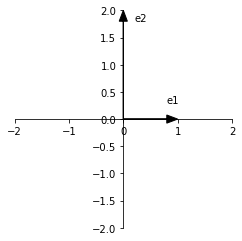

```python
fig = plt.figure()
ax = fig.add_subplot(1,1,1)

ax.spines['left'].set_position('zero')
ax.spines['bottom'].set_position('zero')

ax.spines['right'].set_color('none')
ax.spines['top'].set_color('none')

plt.axis('scaled')
plt.xlim(-2, 2)
plt.ylim(-2, 2)

ax.arrow(0, 0, 0, 2, head_width=0.15, head_length=0.2, length_includes_head=True, facecolor='black')
ax.arrow(0, 0, 1, 0, head_width=0.15, head_length=0.2, length_includes_head=True, facecolor='black')
ax.annotate("e1", xy=(0.8, 0.3))
ax.annotate("e2", xy=(0.2, 1.8))

plt.show()
```

Пример 3 Рассмотрим еще один класс матриц — **симметричные**.

Особенность таких матриц в том, что их можно представить в виде произведения ортогональной матрицы, диагональной и еще одной ортогональной:

$$A=QDQ^{T},$$

где $Q$ — некоторая ортогональная матрица, а $D$ — диагональная матрица.

В контексте линейных преобразований это означает, что сложное преобразование, заданное такой матрицей, можно представить в виде комбинации поворотов и растяжений вдоль осей, задаваемых диагональным и ортогональными компонентами ее разложения.

Столбцы ортогональной матрицы $Q$ из этого разложения содержат ортонормированный базис из *собственных векторов*, а диагональная матрица $D$ содержит *собственные значения* исходной матрицы на главной диагонали.

### Понятие собственного вектора и собственных значений векторов

Важной характеристикой матрицы, а также линейного преобразования, заданного этой матрицей, является спектр — набор собственных векторов и соответствующих собственных значений.

Собственный вектор оператора 𝐀 — это такой ненулевой вектор, действие оператора на который сводится к умножению его на число:

$$\textbf{A}x=\lambda x.$$

При этом число $\lambda$ называется *собственным значением* этого оператора.

Упрощенно говоря, действие оператора $\textbf{A}$ на собственный вектор $x$ заключается в растяжении или сжатии последнего без изменения его направления. Собственные векторы характеризуют направления, в которых оператор растягивает или сжимает векторы без их поворота. То есть геометрический смысл собственных векторов заключается в том, что если ненулевой вектор $x$ является собственным для преобразования $\textbf{A}$, то его образ $\textbf{A}x$ коллинеарен прообразу $x$.

В контексте машинного обучения понятие собственных векторов полезно для охарактеризования наиболее типичных направлений преобразования матрицы. Они применяются для уменьшения матрицы с максимальным сохранением информации в ней (метод опорных векторов).

Понятие собственного вектора используется в Методе Главных Компонент, который предназначен для уменьшения размерности данных с потерей наименьшего количества информации.

**Пример**

Изобразим на плоскости базис из векторов $e_{1}=(1,0)$ и $e_{2}=(0,1)$ в двумерном пространстве:

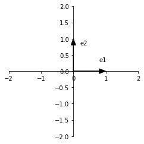

```python
fig = plt.figure()
ax = fig.add_subplot(1,1,1)

ax.spines['left'].set_position('zero')
ax.spines['bottom'].set_position('zero')

ax.spines['right'].set_color('none')
ax.spines['top'].set_color('none')

plt.axis('scaled')
plt.xlim(-2, 2)
plt.ylim(-2, 2)

ax.arrow(0, 0, 0, 1, head_width=0.15, head_length=0.2, length_includes_head=True, facecolor='black')
ax.arrow(0, 0, 1, 0, head_width=0.15, head_length=0.2, length_includes_head=True, facecolor='black')
ax.annotate("e1", xy=(0.8, 0.3))
ax.annotate("e2", xy=(0.2, 0.8))

plt.show()
```

Применим к нему линейное преобразование, заданное матрицей

$$A=\begin{pmatrix} 1 & 1\\ 0 & 1 \end{pmatrix}.$$

И найдем его собственные векторы и собственные значения.

Как говорилось ранее, векторы коэффициентов разложения векторов $g_{i}$ по базису задают столбцы матрицы линейного оператора. Тогда базисные векторы преобразуются следующим образом:

$$Ae_{1}=1\cdot e_{1}+0\cdot e_{2}=e_{1},$$$$Ae_{2}=e_{1}+e_{2}.$$

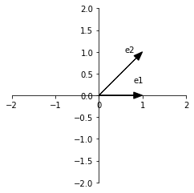

```python
fig = plt.figure()
ax = fig.add_subplot(1,1,1)

ax.spines['left'].set_position('zero')
ax.spines['bottom'].set_position('zero')

ax.spines['right'].set_color('none')
ax.spines['top'].set_color('none')

plt.axis('scaled')
plt.xlim(-2, 2)
plt.ylim(-2, 2)

ax.arrow(0, 0, 1, 1, head_width=0.15, head_length=0.2, length_includes_head=True, facecolor='black')
ax.arrow(0, 0, 1, 0, head_width=0.15, head_length=0.2, length_includes_head=True, facecolor='black')
ax.annotate("e1", xy=(0.8, 0.3))
ax.annotate("e2", xy=(0.6, 1.0))

plt.show()
```

В NumPy собственные векторы и собственные значения оператора вычисляются с помощью функции numpy.linalg.eig(a), где a — матрица этого оператора. В качестве результата она выдает два массива: одномерный массив w собственных чисел и двумерный массив v, в котором по столбцам записаны собственные векторы, так что вектор v[:, i] соотвествует собственному значению w[i].

```python
import numpy as np
np.set_printoptions(precision=2, suppress=True)
```

```python
a = np.array([[1, 1], [0, 1]])
w, v = np.linalg.eig(a)

print(f'Матрица A:\n{a}')
print(f'Собственные значения:\n{w}')
print(f'Собственные векторы:\n{v}')
```

```
Матрица A:
[[1 1]
 [0 1]]
Собственные значения:
[1. 1.]
Собственные векторы:
[[ 1. -1.]
 [ 0.  0.]]
```

```python
b = np.array([[np.sqrt(3)/2, -0.5], [0.5, np.sqrt(3)/2]])
w, v = np.linalg.eig(b)

print(f'Матрица B:\n{b}')
print(f'Собственные значения:\n{w}')
print(f'Собственные векторы:\n{v}')
```

```
Матрица B:
[[ 0.87 -0.5 ]
 [ 0.5   0.87]]
Собственные значения:
[0.87+0.5j 0.87-0.5j]
Собственные векторы:
[[ 0.  -0.71j  0.  +0.71j]
 [-0.71+0.j   -0.71-0.j  ]]
```

## Практическое задание

Все задания рекомендуется делать вручную, затем проверяя полученные результаты с использованием numpy.

**1.** Установить, какие произведения матриц $AB$ и $BA$ определены, и найти размерности полученных матриц:

а) $A$ — матрица $4\times 2$, $B$ — матрица $4\times 2$; $AB$ и $BA$ - неопределены (недопустимая операция)

г) $A$ — квадратная матрица $4\times 4$, $B$ — квадратная матрица $4\times 4$. $AB$ - $4\times 4$; $BA$ - $4\times 4$

**2.** Найти сумму и произведение матриц $A=\begin{pmatrix} 1 & -2\\ 3 & 0 \end{pmatrix}$ и $B=\begin{pmatrix} 4 & -1\\ 0 & 5 \end{pmatrix}.$

**3.** Из закономерностей сложения и умножения матриц на число можно сделать вывод, что матрицы одного размера образуют линейное пространство. Вычислить линейную комбинацию $3A-2B+4C$ для матриц $A=\begin{pmatrix} 1 & 7\\ 3 & -6 \end{pmatrix}$, $B=\begin{pmatrix} 0 & 5\\ 2 & -1 \end{pmatrix}$, $C=\begin{pmatrix} 2 & -4\\ 1 & 1 \end{pmatrix}.$

```python
A = [[1, 7], [3, -6]]
B = [[0, 5], [2 ,-1]]
C = [[2 ,-4],[1, 1]]

print(f"Линейная комбинация  3𝐴 − 2𝐵 + 4𝐶 = \n{matrix_sum(matrix_sum(matrix_times(A,3), matrix_times(B,-2)), matrix_times(C,4))}\n")
```

```
Линейная комбинация  3𝐴 − 2𝐵 + 4𝐶 =
[[ 11  -5]
 [  9 -12]]
```

**4.** Дана матрица $A=\begin{pmatrix} 4 & 1\\ 5 & -2\\ 2 & 3 \end{pmatrix}$. Вычислить $AA^{T}$ и $A^{T}A$.

**5.** Вычислить определитель:

a)

$$\begin{vmatrix} sinx & -cosx\\ cosx & sinx \end{vmatrix};$$

б)

$$\begin{vmatrix} 4 & 2 & 3\\ 0 & 5 & 1\\ 0 & 0 & 9 \end{vmatrix};$$

в)

$$\begin{vmatrix} 1 & 2 & 3\\ 4 & 5 & 6\\ 7 & 8 & 9 \end{vmatrix}.$$

определитель такой матрицы равен 0 т.к если из второй и третьей строки вычесть первую то вторая и третья строки будет линейно зависимыми

**6.** Доказать, что матрица

$$\begin{pmatrix} -2 & 7 & -3\\ 4 & -14 & 6\\ -3 & 7 & 13 \end{pmatrix}$$

вырожденная.

**7.** Найти ранг матрицы:

а) $\begin{pmatrix} 1 & 2 & 3\\ 1 & 1 & 1\\ 2 & 3 & 4 \end{pmatrix};$

## Литература

1. Ильин В. А., Позняк Э. Г. Линейная алгебра: Учеб. для вузов. — 6-е изд. — М.: Физматлит, 2005.

## Дополнительные материалы

1. [Способы задать матрицу в NumPy](https://docs.scipy.org/doc/numpy-1.10.1/user/basics.creation.html).
2. [numpy.transpose](https://docs.scipy.org/doc/numpy-1.10.0/reference/generated/numpy.transpose.html).
3. [array.T](https://docs.scipy.org/doc/numpy-1.10.0/reference/generated/numpy.ndarray.T.html).
4. [Перемножение матриц в NumPy](https://docs.scipy.org/doc/numpy-1.10.0/reference/routines.linalg.html#matrix-and-vector-products).
5. [Определитель матрицы в NumPy](https://docs.scipy.org/doc/numpy-1.14.2/reference/generated/numpy.linalg.det.html)
6. [Ранг матрицы в NumPy](https://docs.scipy.org/doc/numpy-1.14.2/reference/generated/numpy.linalg.matrix_rank.html)
7. [Обращение матриц в NumPy](https://docs.scipy.org/doc/numpy/reference/generated/numpy.linalg.inv.html)